# Master Computational Biology UPM - Programming Challenges: R overview

Beatriz Garcia Jimenez

December, 2018

### R and RStudio

[figure not shown]

[R Project](https://www.r-project.org/) is a free software environment for statistical computing and graphics.  
R is available for [download](https://cran.rstudio.com/) for Linux, Windows and Mac OS X.  
[Tutorial Quick-R](https://www.statmethods.net/r-tutorial/index.html)

[figure not shown]

[Rstudio](https://www.rstudio.com/) is the premier integrated development environment (IDE) for R.  
Rstudio is available for [download](https://www.rstudio.com/products/rstudio/download/) for Linux, Windows and Mac OS X, and it requires R is previously installed.

See [overview video about RStudio](https://vimeo.com/97166163)

### Basic commands:

#### Install and load library:

```r
install.packages("phyloseq")
library(phyloseq)
```

#### Load and run an R script:

When you have an already written R script:

```r
source('scriptR.r')
```

#### Working directory:

wd: **w**orking **d**irectory

```r
getwd() # Find current directory, where input/output files are located by default
setwd('ProgrammingChallenges/PracticeR') # Change the current working directory
```

#### Help:

```r
?write.table
```

### Basic data types:

- **numeric**

```r
varNum <- 4
class(varNum)
```

```
## [1] "numeric"
```

```r
typeof(varNum) # low-level type ('double' or 'complex' (1+3i))
```

```
## [1] "double"
```

- **character**

```r
varChar <- 'myVariable'
class(varChar)
```

```
## [1] "character"
```

- **logical**

```r
varBool <- TRUE
class(varBool)
```

```
## [1] "logical"
```

### Conversion between types

| Function | Description |
| --- | --- |
| as.character(var) | Convert variable *var* to character vector |
| as.numeric(var) | Convert variable *var* to numeric type |
| as.integer(var) | Convert variable *var* to integer type |
| as.logical(var) | Convert variable *var* to TRUE or FALSE |
| as.matrix(var) | Convert variable *var* (i.e. data.frame) to matrix |

Examples:

```r
x <- 5.3
y1 <- as.character(x)
y2 <- as.logical(x)
y3 <- as.integer(x)
x
```

```
## [1] 5.3
```

```r
y1
```

```
## [1] "5.3"
```

```r
y2
```

```
## [1] TRUE
```

```r
y3
```

```
## [1] 5
```

### Data structures:

#### **vector**

##### vector creation:

```r
c(3, 7.5, 2.2) # concat elements
```

```
## [1] 3.0 7.5 2.2
```

```r
c("on", "of", "from") # character vector
```

```
## [1] "on"   "of"   "from"
```

```r
c(TRUE, FALSE, TRUE) # logical vector
```

```
## [1]  TRUE FALSE  TRUE
```

```r
15:23
```

```
## [1] 15 16 17 18 19 20 21 22 23
```

```r
rep(5, times=3) # repeat a element/vector
```

```
## [1] 5 5 5
```

```r
rep(1:2, each=3) # repeat elements of a vector
```

```
## [1] 1 1 1 2 2 2
```

```r
seq(from=2, to=5, by=0.5) # sequence
```

```
## [1] 2.0 2.5 3.0 3.5 4.0 4.5 5.0
```

##### vector element access by position [index]

```r
v <- c(3, 5, 10, 15, 18, 25)
v[2]
```

```
## [1] 5
```

```r
v[1:3]
```

```
## [1]  3  5 10
```

```r
v[c(2,4,6)] # Indices generated from other vector
```

```
## [1]  5 15 25
```

##### vector element access by value (comparisons)

```r
v <- c(3, 5, 10, 15, 18, 25)
v[v == 10]
```

```
## [1] 10
```

```r
v[v < 15]
```

```
## [1]  3  5 10
```

```r
v[v %in% c(1,3,5)]
```

```
## [1] 3 5
```

##### vector operations: All elements at once:

```r
v1 <- c(10,12,15,20)
v1
```

```
## [1] 10 12 15 20
```

```r
v2 <- 1:4
v2
```

```
## [1] 1 2 3 4
```

```r
3 * v1  # A (scalar) number with all vector elements
```

```
## [1] 30 36 45 60
```

```r
v1 + v2 # One by one element operations between two equal-length vectors
```

```
## [1] 11 14 18 24
```

#### **string**:

- String is a character vector. There are specific functions defined to make easy the string management.

Concatenate several strings (x, y)

```r
paste(x, y, sep = '')
```

Number of characters in the string

```r
nchar(x)
```

Retrive part of the string, limited by *ini* and *end*

```r
substring(x, ini, end)
```

Find regular expresion (pattern) matches in string x

```r
grep(pattern, x)
```

Replace matches of regular expresion (pattern) in string x with a new string (replace)

```r
gsub(pattern, replace, x)
```

Convert to uppercase/lowercase

```r
toupper(x)
tolower(x)
```

Examples:

```r
paste('Hello',"word")
```

```
## [1] "Hello word"
```

```r
sequence='ACTGCGTCCGATTAGTACTTAtGTCGATCGATCGATCAGTCCAGTCA'
substring(sequence,15,nchar(sequence))
```

```
## [1] "GTACTTAtGTCGATCGATCGATCAGTCCAGTCA"
```

```r
grep('UA',sequence)
```

```
## integer(0)
```

```r
grep('AT',sequence)
```

```
## [1] 1
```

```r
gsub('AT','--',sequence)
```

```
## [1] "ACTGCGTCCG--TAGTACTTAtGTCG--CG--CG--CAGTCCAGTCA"
```

```r
tolower(sequence)
```

```
## [1] "actgcgtccgattagtacttatgtcgatcgatcgatcagtccagtca"
```

More string functions in *stringr* library.

#### **matrix**

- Data structures as vector although with 2 or more dimensions. Matrix creation:

```r
m <- matrix(data = NA, nrow = 1, ncol = 1, byrow = FALSE)
```

Access matrix element, by indeces:

```r
m[indexRow,indexColumn]
```

Examples:

```r
# Creation
matrix(1:6, 2, 3)
```

```
##      [,1] [,2] [,3]
## [1,]    1    3    5
## [2,]    2    4    6
```

```r
m<-matrix(1:9, 3, 3, byrow = T)
m
```

```
##      [,1] [,2] [,3]
## [1,]    1    2    3
## [2,]    4    5    6
## [3,]    7    8    9
```

```r
# Dimensions
dim(m)
```

```
## [1] 3 3
```

```r
# Access
m[2,3]
```

```
## [1] 6
```

```r
m[2:3,c(1,3)]
```

```
##      [,1] [,2]
## [1,]    4    6
## [2,]    7    9
```

```r
# Operation
m+10
```

```
##      [,1] [,2] [,3]
## [1,]   11   12   13
## [2,]   14   15   16
## [3,]   17   18   19
```

#### **factor**

- Similar to character vector, but with values restricted to specific levels (categories). Internally, it is represented as integers. Each level has associated a representative string. Useful to count or for statistical purposes.

```r
varFac <- factor(c('apple','orange','grapes','orange','apple','apple'))
varFac
```

```
## [1] apple  orange grapes orange apple  apple
## Levels: apple grapes orange
```

```r
class(varFac)
```

```
## [1] "factor"
```

```r
levels(varFac)
```

```
## [1] "apple"  "grapes" "orange"
```

```r
varFac=="orange"
```

```
## [1] FALSE  TRUE FALSE  TRUE FALSE FALSE
```

```r
table(varFac)
```

```
## varFac
##  apple grapes orange
##      3      1      2
```

#### **list**

- Sucesive objects, that could be of different length and types

```r
genes = list(
    coding=c("BRCA2", "CFTR", "GAPDH"),
    nonCoding=c("gXX", "gYY")
)
genes
```

```
## $coding
## [1] "BRCA2" "CFTR"  "GAPDH"
##
## $nonCoding
## [1] "gXX" "gYY"
```

[ subsets one list to create another list  
[[ extracts a list element

```r
genes[1]
```

```
## $coding
## [1] "BRCA2" "CFTR"  "GAPDH"
```

```r
class(genes[1])
```

```
## [1] "list"
```

```r
genes["nonCoding"]
```

```
## $nonCoding
## [1] "gXX" "gYY"
```

```r
genes[["coding"]]
```

```
## [1] "BRCA2" "CFTR"  "GAPDH"
```

```r
class(genes[["coding"]])
```

```
## [1] "character"
```

#### **data.frame**

- Most common R data structures to store tables. It contains several vectors of the same length, but whatever type. Each column or/and row could have a name/header. It could be consider a special type of list, where the different objects are the same length (although different types)

Creation:

```r
dfEcoliGenes <- data.frame(item=1:4,
            id=as.factor(c('JW4367', 'JW0001', 'JW0002', 'JW0003')),
            name=c('thrL','thrA','thrB','thrC'),
            length=c(21,820,310,428))
dfEcoliGenes
```

```
##   item     id name length
## 1    1 JW4367 thrL     21
## 2    2 JW0001 thrA    820
## 3    3 JW0002 thrB    310
## 4    4 JW0003 thrC    428
```

Data frames are usually read from big tables in text (comma or tab separated) files:

```r
df=read.table('tableEnsembl.tsv',sep="\t",header=TRUE,quote="",stringsAsFactors = FALSE)
```

Useful data frame functions:

| Function | Description |
| --- | --- |
| *str(df)* | Check type structure |
| *head(df)* | Check first *df* rows. Check the content was right loaded. |
| *tail(df)* | Check last *df* rows |
| *colnames(df)* | Vector with column names |
| *rownames(df)* | Vector with row names |
| *nrow(df)*, *ncol(df)*, *dim(df)* | Row or column number (or both) |

head/tail are very useful in big data frames.

Examples:

```r
str(df)
```

```
## 'data.frame':    2750 obs. of  6 variables:
##  $ ensembl_gene_id           : chr  "ENSG00000178591" "ENSG00000125788" "ENSG00000088782" "ENSG00000185982" ...
##  $ chromosome_name           : int  20 20 20 20 20 20 20 20 20 20 ...
##  $ start_position            : int  87250 142369 157470 187853 227258 257736 267186 270863 296968 320313 ...
##  $ end_position              : int  97094 145751 159163 189681 229886 261096 268857 290778 300321 348224 ...
##  $ percentage_gene_gc_content: num  37.8 35.4 39.9 41.4 39.9 ...
##  $ description               : chr  "defensin beta 125 [Source:HGNC Symbol;Acc:HGNC:18105]" "defensin beta 126 [Source:HGNC Symbol;Acc:HGNC:15900]" "defensin beta 127 [Source:HGNC Symbol;Acc:HGNC:16206]" "defensin beta 128 [Source:HGNC Symbol;Acc:HGNC:18106]" ...
```

```r
head(df)
```

```
##   ensembl_gene_id chromosome_name start_position end_position
## 1 ENSG00000178591              20          87250        97094
## 2 ENSG00000125788              20         142369       145751
## 3 ENSG00000088782              20         157470       159163
## 4 ENSG00000185982              20         187853       189681
## 5 ENSG00000125903              20         227258       229886
## 6 ENSG00000186458              20         257736       261096
##   percentage_gene_gc_content
## 1                      37.75
## 2                      35.41
## 3                      39.85
## 4                      41.39
## 5                      39.94
## 6                      42.90
##                                             description
## 1 defensin beta 125 [Source:HGNC Symbol;Acc:HGNC:18105]
## 2 defensin beta 126 [Source:HGNC Symbol;Acc:HGNC:15900]
## 3 defensin beta 127 [Source:HGNC Symbol;Acc:HGNC:16206]
## 4 defensin beta 128 [Source:HGNC Symbol;Acc:HGNC:18106]
## 5 defensin beta 129 [Source:HGNC Symbol;Acc:HGNC:16218]
## 6 defensin beta 132 [Source:HGNC Symbol;Acc:HGNC:33806]
```

```r
tail(df)
```

```
##      ensembl_gene_id chromosome_name start_position end_position
## 2745 ENSG00000225929              22       50735825     50738139
## 2746 ENSG00000100312              22       50738196     50745334
## 2747 ENSG00000254499              22       50740593     50743520
## 2748 ENSG00000213683              22       50754675     50755434
## 2749 ENSG00000184319              22       50756948     50801309
## 2750 ENSG00000079974              22       50767501     50783663
##      percentage_gene_gc_content
## 2745                      45.79
## 2746                      55.48
## 2747                      52.94
## 2748                      47.24
## 2749                      44.54
## 2750                      50.05
##                                                                        description
## 2745                 uncharacterized LOC105373100 [Source:NCBI gene;Acc:105373100]
## 2746                                     acrosin [Source:HGNC Symbol;Acc:HGNC:126]
## 2747                                                              novel transcript
## 2748            small nuclear ribonucleoprotein polypeptide A' (SNRPA1) pseudogene
## 2749      ribosomal protein L23a pseudogene 82 [Source:HGNC Symbol;Acc:HGNC:33730]
## 2750 RAB, member of RAS oncogene family like 2B [Source:HGNC Symbol;Acc:HGNC:9800]
```

```r
colnames(df)
```

```
## [1] "ensembl_gene_id"            "chromosome_name"
## [3] "start_position"             "end_position"
## [5] "percentage_gene_gc_content" "description"
```

```r
head(rownames(df))
```

```
## [1] "1" "2" "3" "4" "5" "6"
```

```r
dim(df)
```

```
## [1] 2750    6
```

##### Data frame access and filtering:

- See the content of only one column (`data.frame$column`):

```r
dfEcoliGenes$item
```

[output not shown]

- See the content of only one row (`data.frame[row,]`) Empty column means to retrieve all columns

```r
dfEcoliGenes[1,]
```

```
##   item     id name length
## 1    1 JW4367 thrL     21
```

or only one column/attribute (`data.frame[[columnNum/columnName]]`)

```r
dfEcoliGenes$id
```

```
## [1] JW4367 JW0001 JW0002 JW0003
## Levels: JW0001 JW0002 JW0003 JW4367
```

```r
dfEcoliGenes[[2]]
```

```
## [1] JW4367 JW0001 JW0002 JW0003
## Levels: JW0001 JW0002 JW0003 JW4367
```

```r
dfEcoliGenes[["id"]]
```

```
## [1] JW4367 JW0001 JW0002 JW0003
## Levels: JW0001 JW0002 JW0003 JW4367
```

- Changing variables names (to simplify access):

```r
colnames(df)
```

```
## [1] "ensembl_gene_id"            "chromosome_name"
## [3] "start_position"             "end_position"
## [5] "percentage_gene_gc_content" "description"
```

```r
colnames(df)[1]="ID"
colnames(df)[2]="chr"
colnames(df)[3]="start"
colnames(df)[4]="end"
colnames(df)[5]="GCperc"
colnames(df)
```

```
## [1] "ID"          "chr"         "start"       "end"         "GCperc"
## [6] "description"
```

```r
head(df$ID)
```

```
## [1] "ENSG00000178591" "ENSG00000125788" "ENSG00000088782" "ENSG00000185982"
## [5] "ENSG00000125903" "ENSG00000186458"
```

```r
head(df$GCperc)
```

```
## [1] 37.75 35.41 39.85 41.39 39.94 42.90
```

- Save and load an R object, for future use:

```r
save(df, file='myHumanGeneTable.RData')
load('myHumanGeneTable.RData')
```

- Scale the values of a column vector:

```r
head(df$GCperc/100)
```

```
## [1] 0.3775 0.3541 0.3985 0.4139 0.3994 0.4290
```

- Compute the maximum of a column vector:

```r
max(df$GCperc)
```

```
## [1] 92.86
```

- Compute the mean of a column vector:

```r
mean(df$GCperc)
```

```
## [1] 49.78413
```

- Add a new column:

```r
df$length = df$end - df$start
```

- Select columns, given column names:

```r
dfi=subset(df,select=c("ID","chr","length","GCperc"))
# or dfi=df[,c("ID","chr","length","GCperc")]
head(dfi)
```

```
##                ID chr length GCperc
## 1 ENSG00000178591  20   9844  37.75
## 2 ENSG00000125788  20   3382  35.41
## 3 ENSG00000088782  20   1693  39.85
## 4 ENSG00000185982  20   1828  41.39
## 5 ENSG00000125903  20   2628  39.94
## 6 ENSG00000186458  20   3360  42.90
```

```r
ncol(dfi) # number of columns
```

```
## [1] 4
```

```r
nrow(dfi) # number of rows
```

```
## [1] 2750
```

- Select rows, given a column value (i.e. one independent chromosome):

```r
dfx = subset(dfi, chr=='22')
nrow(dfx)
```

```
## [1] 1353
```

or several values:

```r
dfx=subset(dfi, chr %in% c('20','22')
```

or given a logical expression (length > 1000):

```r
dfx = subset(dfi, length > 1000)
nrow(dfx)
```

```
## [1] 1798
```

or remove rows, given several column values:

```r
dfx=subset(dfi,!(ID %in% c('ENSG00000277248','ENSG00000283047')))
nrow(dfx)
```

```
## [1] 2748
```

or several conditions to filter the rows (for example, chromosome 22 AND (&) removing sequences shorther than 2000):

```r
dfx = subset(dfi, chr=='22' & length>2000)
nrow(dfx)
```

```
## [1] 764
```

For an alternative condition, to use OR (|)

**Exercises:**

1. Compute the mean length of the human genes in ‘tableEnsembl.tsv’ which starts in the first 1000000 positions.
2. Which is the distribution of genes with a GC percentage between 30 and 40%? Plot an histogram

#### tibble (dplyr, tidyverse)

- The *tibble* data structure makes sense when it works together with the *tidyverse* library, which is a collection of R packages designed for data science, including the important *dplyr* among others. A short comparison between tibble and data.frame could be explored in the [tibble vignette](https://cran.r-project.org/web/packages/tibble/vignettes/tibble.html)

Compare printing data.frame vs tibble:

```r
library(tibble,quietly=TRUE)
library(dplyr,quietly=TRUE)
tibb=as_tibble(df)
tibb
```

```
## # A tibble: 2,750 x 7
##    ID         chr  start    end GCperc description                  length
##    <chr>    <int>  <int>  <int>  <dbl> <chr>                         <int>
##  1 ENSG000…    20  87250  97094   37.8 defensin beta 125 [Source:H…   9844
##  2 ENSG000…    20 142369 145751   35.4 defensin beta 126 [Source:H…   3382
##  3 ENSG000…    20 157470 159163   39.8 defensin beta 127 [Source:H…   1693
##  4 ENSG000…    20 187853 189681   41.4 defensin beta 128 [Source:H…   1828
##  5 ENSG000…    20 227258 229886   39.9 defensin beta 129 [Source:H…   2628
##  6 ENSG000…    20 257736 261096   42.9 defensin beta 132 [Source:H…   3360
##  7 ENSG000…    20 267186 268857   50   novel transcript               1671
##  8 ENSG000…    20 270863 290778   48.4 chromosome 20 open reading …  19915
##  9 ENSG000…    20 296968 300321   55.2 zinc finger CCHC-type conta…   3353
## 10 ENSG000…    20 320313 348224   52   NRSN2 antisense RNA 1 [Sour…  27911
## # ... with 2,740 more rows
```

```r
#df
head(df)
```

```
##                ID chr  start    end GCperc
## 1 ENSG00000178591  20  87250  97094  37.75
## 2 ENSG00000125788  20 142369 145751  35.41
## 3 ENSG00000088782  20 157470 159163  39.85
## 4 ENSG00000185982  20 187853 189681  41.39
## 5 ENSG00000125903  20 227258 229886  39.94
## 6 ENSG00000186458  20 257736 261096  42.90
##                                             description length
## 1 defensin beta 125 [Source:HGNC Symbol;Acc:HGNC:18105]   9844
## 2 defensin beta 126 [Source:HGNC Symbol;Acc:HGNC:15900]   3382
## 3 defensin beta 127 [Source:HGNC Symbol;Acc:HGNC:16206]   1693
## 4 defensin beta 128 [Source:HGNC Symbol;Acc:HGNC:18106]   1828
## 5 defensin beta 129 [Source:HGNC Symbol;Acc:HGNC:16218]   2628
## 6 defensin beta 132 [Source:HGNC Symbol;Acc:HGNC:33806]   3360
```

Some useful functions in dplyr with tibble:

- Filter with tibble (and dplyr):

```r
dplyr::filter(tibb, chr=='22')
```

```
## # A tibble: 1,353 x 7
##    ID         chr   start    end GCperc description                 length
##    <chr>    <int>   <int>  <int>  <dbl> <chr>                        <int>
##  1 ENSG000…    22  1.07e7 1.07e7   31.9 ""                             112
##  2 ENSG000…    22  1.09e7 1.10e7   35.2 FSHD region gene 1 family …  21950
##  3 ENSG000…    22  1.11e7 1.11e7   60.3 novel transcript              1756
##  4 ENSG000…    22  1.11e7 1.11e7   42.6 ACTR3B pseudogene 6 [Sourc…   1368
##  5 ENSG000…    22  1.12e7 1.12e7   50.3 ""                             150
##  6 ENSG000…    22  1.26e7 1.26e7   35.8 FSHD region gene 1 family …  24176
##  7 ENSG000…    22  1.53e7 1.53e7   40.2 ""                             106
##  8 ENSG000…    22  1.53e7 1.53e7   40.3 novel transcript              6113
##  9 ENSG000…    22  1.53e7 1.53e7   33.4 Ankyrin repeat domain 30A …   6478
## 10 ENSG000…    22  1.53e7 1.53e7   37.7 novel transcript              6178
## # ... with 1,343 more rows
```

- Select columns:

```r
dplyr::select(tibb, description)
```

```
## # A tibble: 2,750 x 1
##    description
##    <chr>
##  1 defensin beta 125 [Source:HGNC Symbol;Acc:HGNC:18105]
##  2 defensin beta 126 [Source:HGNC Symbol;Acc:HGNC:15900]
##  3 defensin beta 127 [Source:HGNC Symbol;Acc:HGNC:16206]
##  4 defensin beta 128 [Source:HGNC Symbol;Acc:HGNC:18106]
##  5 defensin beta 129 [Source:HGNC Symbol;Acc:HGNC:16218]
##  6 defensin beta 132 [Source:HGNC Symbol;Acc:HGNC:33806]
##  7 novel transcript
##  8 chromosome 20 open reading frame 96 [Source:HGNC Symbol;Acc:HGNC:16227]
##  9 zinc finger CCHC-type containing 3 [Source:HGNC Symbol;Acc:HGNC:16230]
## 10 NRSN2 antisense RNA 1 [Source:HGNC Symbol;Acc:HGNC:51222]
## # ... with 2,740 more rows
```

- Pipes: Pipe (%>%) operator provides help to concatenate function calls in a readable and easy way, instead of a long sequence.

```r
tibb %>%
  dplyr::filter(chr=='22') %>%
  dplyr::filter(GCperc>45) %>%
  dplyr::select(ID,description)
```

```
## # A tibble: 1,069 x 2
##    ID            description
##    <chr>         <chr>
##  1 ENSG00000279… novel transcript
##  2 ENSG00000276… ""
##  3 ENSG00000215… ubiquitin specific peptidase 10 (USP10) pseudogene
##  4 ENSG00000213… single stranded DNA binding protein 3 (SSBP3) pseudogene
##  5 ENSG00000230… chromosome 10 open reading frame 57 (C10orf57) pseudogene
##  6 ENSG00000230… novel transcript
##  7 ENSG00000226… nitric oxide synthase 2A (inducible, hepatocytes) (NOS2A…
##  8 ENSG00000234… mediator complex subunit 15 pseudogene 7 [Source:HGNC Sy…
##  9 ENSG00000241… actin, beta (ACTB) pseudogene
## 10 ENSG00000235… GRAM domain containing 4 pseudogene 2 [Source:HGNC Symbo…
## # ... with 1,059 more rows
```

```r
# instead of: dplyr::select(dplyr::filter(dplyr::filter(tibb, chr=='22'),GCperc>45), ID, description)
```

- Group by:

```r
tibb %>% group_by(chr) %>% summarise(mean(GCperc))
```

```
## # A tibble: 2 x 2
##     chr `mean(GCperc)`
##   <int>          <dbl>
## 1    20           48.5
## 2    22           51.2
```

#### data.table

- data.table is a data structure to enhance the R standard structure, it is, the data.frame.

The syntaxis of this new data structure compared with could be explored in the [vignette of the data.table library](https://cran.r-project.org/web/packages/data.table/vignettes/datatable-intro.html)

**Note:** In general, both data structures (tibble with dplyr and data.table) are suitable to manage big tables. However, when you table is huge (~millions of rows), data.table is the fastest, although tibble with dplyr provides more kind syntaxis. (Sources comparison dplyr and data.table packages: https://freakonometrics.hypotheses.org/19645, https://dlegorreta.wordpress.com/r-vs-r-realmente-es-dplyr-vs-data-table/)

* **Note:** Additionally, you could design your self user-defined data class. Some examples of this advanced use below (i.e. mart, phyloseq class)

### Read/Write tables in a file (data.frame)

```r
df=read.table('tableEnsembl.tsv',sep="\t",header=TRUE,quote="",stringsAsFactors = FALSE)

write.table(df,file='tableEnsembl.tsv',quote=FALSE,sep="\t",row.names=FALSE)
```

`sep` parameter represents the field separator character

- sep=“,” if columns split by ‘,’
- sep=“\t” if columns split by tab

### Check the data structure/class/type:

typeof(), class()

```r
v <- c(3, 5, 10, 15, 18, 25)
typeof(v)
```

```
## [1] "double"
```

```r
typeof(v)
```

```
## [1] "double"
```

```r
c <- "Checking data type"
class(c)
```

```
## [1] "character"
```

### Missing data and special values

- NA (Not Available): identification of missing data in R (for example, when there is an empty cell in a table read from a file)

```r
x <- c("a", NA, "c", "d", NA)
is.na(x)
```

```
## [1] FALSE  TRUE FALSE FALSE  TRUE
```

```r
anyNA(x)
```

```
## [1] TRUE
```

- NaN (Not a Number)
- Inf (Infinite)

### Function definition

To modulate and organize the code in independent blocks.

```r
# Function definition
functionName <- function(param1, param2=defaultValueParam2,...)
{
  <instructions>
  ...
  return(result)
}
# Call to the function
a=functionName(34,'ABCD')
```

### Bioconductor

How to install packages designed for bioinformatics operations with biological data.

```r
source("http://bioconductor.org/biocLite.R")
biocLite() # Install basic bioinformatics packages
biocLite('biomaRt') # Install additional ones
```

One of the useful packages in Bioconductor is *biomaRt*, allowing access to Ensembl repository through programmatic access with R:

```r
library(biomaRt)
```

First, you need to define a *mart* object with the specific dataset. For example, to use human ensembl one:

```r
ensembl <- useMart("ensembl", dataset = "hsapiens_gene_ensembl")
```

Then, the main retrievement function of the biomaRt package is `getBM()`

```r
resEnsembl <- getBM(attributes =  myAttributes, filters =  myFilter,
             values =  myValues, mart = ensembl)
```

where, you must define:  
* the *attributes* you want to retrieve as output properties of each register (i.e. gene/protein). They must be included in the available list.  
* the *filters* to apply as input in the query. Also, they must be selected from the provided list.  
* the vector of *values* of the filter. If there are several filters, several vectors are expected, in the same order than in the *filters* argument.  
* the *mart* object (biomart dataset) where do the search, previously defined with *useMart()*

For example, the query to find all genes within chromosomes 20 and 22, described by their start and end position, % GC and gene textual description, would be:

```r
# A) Define arguments:
# Define attributes
myAttributes <- c("ensembl_gene_id","chromosome_name","start_position","end_position","percentage_gene_gc_content","description")
# From the available attribute list
#listAttributes(ensembl) # all possible ones
head(listAttributes(ensembl), 25)
```

```
##                               name
## 1                  ensembl_gene_id
## 2          ensembl_gene_id_version
## 3            ensembl_transcript_id
## 4    ensembl_transcript_id_version
## 5               ensembl_peptide_id
## 6       ensembl_peptide_id_version
## 7                  ensembl_exon_id
## 8                      description
## 9                  chromosome_name
## 10                  start_position
## 11                    end_position
## 12                          strand
## 13                            band
## 14                transcript_start
```

[output cut: 37 more lines]

```r
# Define filters
myFilter <- "chromosome_name"
# From the available filter list
#listFilters(ensembl)
head(listFilters(ensembl), 25)
```

```
##                                   name
## 1                      chromosome_name
## 2                                start
## 3                                  end
## 4                           band_start
## 5                             band_end
## 6                         marker_start
## 7                           marker_end
## 8                        encode_region
## 9                               strand
## 10                  chromosomal_region
## 11                           with_ccds
## 12                         with_chembl
## 13       with_clone_based_ensembl_gene
## 14 with_clone_based_ensembl_transcript
```

[output cut: 37 more lines]

```r
# Define a vector of values of filter
myValues <- c("20", "22")

# B) Assemble and query biomart:
resEnsembl <- getBM(attributes =  myAttributes, filters =  myFilter,
             values =  myValues, mart = ensembl)
```

**Exercises:**

1. Find all the human genes (at least, ensembl identifiers and gene description) annotated with “sucrose alpha-glucosidase activity” in Gene Ontology.
2. Annotate these genes (EntrezGene IDs: 123, 288, 358) with Reactome and Pfam domain annotations
3. Find the protein sequences for the next given identifiers: 123, 288, 358

### phyloseq: microbiome data manipulation

phyloseq is an R package included in Bioconductor to work with microbiome data.  
[website](https://joey711.github.io/phyloseq/index.html)  
[McMurdie and Holmes, 2013](https://doi.org/10.1371/journal.pone.0061217)

phyloseq defines its self data structure, composed by:

- **OTU table**: matrix with OTU abundances in each cell, with samples in columns and OTUs in rows.
- **taxonomy**: matrix with up to seven levels of the taxonomic classification associated to each OTU. Taxonomic levels in columns and OTUs in rows. If some level is unknown in a sample, it could be labeled as NA.
- **sampling**: list of different vectors, with one vector per attribute or property describing each microbiome sample.
- (Optionally: phylogenetic tree and sequences)

phyloseq provides multiple functions to access, filter or visualize microbiome data loaded in its phyloseq format.

#### Input data

To create a phyloseq object you always require (other elements are optional):

- OTU table
- sample data

There are two main options to import the data to get a phyloseq object:

- file in standard biom format (http://biom-format.org/) (i.e. OTU table). You additionally could add phylogenetic tree and sequences are additional parameters in `import_biom()`. The sampling data should be imported independently, depending on its format (.csv, qiime, etc).

```r
biom.otu<-import_biom(biomFile)
map<-import_qiime_sample_data(mapBiomFile)
data <- merge_phyloseq(biom.otu,map)
```

There are similar functions for OTU input file in other format (qiime, mothur, etc.)

- OTU table and mapping in csv/tsv format. In this case, you first read the table as a data.frame (`read.table()`), and after you convert it to a otu_table in the phyloseq required format (`otu_table()`). The same procedure should be follow for the mapping file (using `read.table()` and `sample_data()` in this case). Finally, to join both objects in a phyloseq one you should call `merge_phyloseq()` or the constructor `phyloseq()`.

```r
otumat <- t(read.table('otu.table.tsv',sep='\t',row.names=1,header=TRUE,quote=""))
OTU = otu_table(otumat, taxa_are_rows = TRUE)
mapmat <- read.table('mapping.tsv',sep='\t',row.names=1,header=TRUE)
MAP = sample_data(mapmat)
data = phyloseq(OTU, MAP)
```

phyloseq provides some objects to test the packages, that you could load with `data()`:

```r
library(phyloseq)
data(GlobalPatterns) # include environmental samples and some mock communities.
```

or as whatever R data, you could `load()` a phyloseq object previously saved in a file:

```r
load('Ballou2016.Rdata') # chick gut samples, treated with probiotics and/or Salmonella vaccine
ballou2016
```

```
## phyloseq-class experiment-level object
## otu_table()   OTU Table:         [ 1583 taxa and 118 samples ]
## sample_data() Sample Data:       [ 118 samples by 41 sample variables ]
## tax_table()   Taxonomy Table:    [ 1583 taxa by 7 taxonomic ranks ]
```

#### Access phyloseq components

Check the different elements of the loaded phyloseq object:

```r
head(otu_table(ballou2016),1)
```

```
## OTU Table:          [1 taxa and 118 samples]
##                      taxa are rows
##        10291.d28.sc.a4 10291.d28.cp.a4 10291.d28.cc.a1 10291.d28.sp.a6
## 357765             170              70             247             101
##        10291.d28.cc.a4 10291.d28.cp.a1 10291.d28.sp.a3 10291.d28.sp.a5
## 357765             146              34             147             122
##        10291.d28.sp.a4 10291.d28.sp.a1 10291.d28.cc.a2 10291.d28.cc.a5
## 357765             101             126             142             133
##        10291.d28.cp.a5 10291.d28.cc.a6 10291.d28.sc.a2 10291.d28.cc.a3
## 357765             104              58              82              61
##        10291.d14.sc.a4 10291.d28.cp.a3 10291.d14.sc.a3 10291.d28.sp.a2
## 357765              35              29              55             156
##        10291.d14.sc.a5 10291.d28.cp.a6 10291.d28.sc.a5 10291.d28.sc.a3
## 357765              34              55              54               2
##        10291.d28.sc.a1 10291.d3.cp.a2 10291.d28.sc.a6 10291.d7.cp.a5
## 357765               2              1               4              2
##        10291.d14.sp.a6 10291.d7.cp.a2 10291.d14.cc.a1 10291.d14.cc.a6
## 357765               0              0               0               0
##        10291.d0.cp.a1 10291.d14.sp.a1 10291.d14.cc.a5 10291.d3.cc.a6
## 357765              0               0               0              0
##        10291.d14.sp.a2 10291.d14.sp.a5 10291.d14.sp.a3 10291.d7.sp.a3
## 357765               0               0               0              0
##        10291.d3.cp.a5 10291.d7.sp.a5 10291.d7.sp.a1 10291.d14.cc.a4
## 357765              0              0              0               0
##        10291.d14.cc.a3 10291.d7.sc.a2 10291.d14.cp.a3 10291.d14.sc.a1
## 357765               0              0               0               0
##        10291.d7.sp.a4 10291.d7.sc.a5 10291.d1.cp.a1 10291.d7.sp.a2
## 357765              0              0              0              0
##        10291.d14.cp.a2 10291.d3.cp.a4 10291.d14.cp.a6 10291.d7.cp.a3
## 357765               0              0               0              0
##        10291.d7.sp.a6 10291.d3.cp.a6 10291.d14.cp.a5 10291.d14.sc.a2
## 357765              0              0               0               0
##        10291.d14.cp.a4 10291.d7.cp.a4 10291.d7.cp.a6 10291.d7.sc.a6
## 357765               0              0              0              0
##        10291.d7.sc.a1 10291.d14.cc.a2 10291.d7.cp.a1 10291.d3.sp.a6
## 357765              0               0              0              0
##        10291.d3.cc.a3 10291.d3.sp.a3 10291.d3.sc.a5 10291.d3.sp.a2
## 357765              0              0              0              0
##        10291.d7.sc.a3 10291.d14.sc.a6 10291.d7.sc.a4 10291.d0.cp.a4
## 357765              0               0              0              0
##        10291.d1.sc.a2 10291.d3.sc.a2 10291.d1.cc.a1 10291.d0.sc.a5
## 357765              0              0              0              0
##        10291.d0.cc.a2 10291.d0.cc.a6 10291.d7.cc.a5 10291.d0.sp.a5
## 357765              0              0              0              0
##        10291.d3.sc.a3 10291.d0.cc.a5 10291.d7.cc.a3 10291.d1.cc.a5
## 357765              0              0              0              0
##        10291.d3.cc.a5 10291.d1.cc.a6 10291.d7.cc.a6 10291.d3.cc.a4
## 357765              0              0              0              0
##        10291.d0.cc.a3 10291.d7.cc.a4 10291.d1.sc.a6 10291.d3.sp.a1
## 357765              0              0              0              0
##        10291.d1.sc.a5 10291.d3.sc.a4 10291.d1.cp.a3 10291.d7.cc.a1
## 357765              0              0              0              0
##        10291.d1.cp.a2 10291.d3.cc.a1 10291.d1.cp.a6 10291.d3.cp.a1
## 357765              0              0              0              0
##        10291.d3.cc.a2 10291.d1.sc.a1 10291.d3.sp.a5 10291.d0.cp.a2
## 357765              0              0              0              0
##        10291.d1.cc.a3 10291.d3.sc.a1 10291.d0.cp.a6 10291.d3.cp.a3
## 357765              0              0              0              0
##        10291.d1.cc.a2 10291.d1.sp.a1 10291.d0.cc.a1 10291.d1.sc.a4
## 357765              0              0              0              0
##        10291.d3.sp.a4 10291.d1.sp.a6
## 357765              0              0
```

```r
head(sample_data(ballou2016))
```

```
##                      X.SampleID BarcodeSequence   LinkerPrimerSequence
## 10291.d28.sc.a4 10291.d28.sc.a4    TAGCGCGAACTT CCGGACTACHVGGGTWTCTAAT
## 10291.d28.cp.a4 10291.d28.cp.a4    CCTAGTAAGCTG CCGGACTACHVGGGTWTCTAAT
## 10291.d28.cc.a1 10291.d28.cc.a1    TAGACCGACTCC CCGGACTACHVGGGTWTCTAAT
## 10291.d28.sp.a6 10291.d28.sp.a6    TTCTGAGAGGTA CCGGACTACHVGGGTWTCTAAT
## 10291.d28.cc.a4 10291.d28.cc.a4    GGCGTTGCATTC CCGGACTACHVGGGTWTCTAAT
## 10291.d28.cp.a1 10291.d28.cp.a1    TACGGATTATGG CCGGACTACHVGGGTWTCTAAT
##                 age_prep  center_name collection_timestamp_prep
## 10291.d28.sc.a4       28 ANL IGSB-NGS               5/3/11 9:00
## 10291.d28.cp.a4       28 ANL IGSB-NGS               5/3/11 9:00
## 10291.d28.cc.a1       28 ANL IGSB-NGS               5/3/11 9:00
## 10291.d28.sp.a6       28 ANL IGSB-NGS               5/3/11 9:00
## 10291.d28.cc.a4       28 ANL IGSB-NGS               5/3/11 9:00
## 10291.d28.cp.a1       28 ANL IGSB-NGS               5/3/11 9:00
##                 description_prep    diet_age_prep diet_treatment_prep
## 10291.d28.sc.a4        d28_sc_a4       Control_28             Control
## 10291.d28.cp.a4        d28_cp_a4 0.1%_PrimaLac_28       0.1%_PrimaLac
## 10291.d28.cc.a1        d28_cc_a1       Control_28             Control
## 10291.d28.sp.a6        d28_sp_a6 0.1%_PrimaLac_28       0.1%_PrimaLac
## 10291.d28.cc.a4        d28_cc_a4       Control_28             Control
## 10291.d28.cp.a1        d28_cp_a1 0.1%_PrimaLac_28       0.1%_PrimaLac
##                 dna_extracted_prep
## 10291.d28.sc.a4               True
## 10291.d28.cp.a4               True
## 10291.d28.cc.a1               True
## 10291.d28.sp.a6               True
## 10291.d28.cc.a4               True
## 10291.d28.cp.a1               True
##                                                                       experiment_design_description
## 10291.d28.sc.a4 microbial 16S timeseries of cecal community development in chicks with 4 treatments
## 10291.d28.cp.a4 microbial 16S timeseries of cecal community development in chicks with 4 treatments
## 10291.d28.cc.a1 microbial 16S timeseries of cecal community development in chicks with 4 treatments
## 10291.d28.sp.a6 microbial 16S timeseries of cecal community development in chicks with 4 treatments
## 10291.d28.cc.a4 microbial 16S timeseries of cecal community development in chicks with 4 treatments
## 10291.d28.cp.a1 microbial 16S timeseries of cecal community development in chicks with 4 treatments
##                                  library_construction_protocol
## 10291.d28.sc.a4 earth microbiome project recommended protocols
## 10291.d28.cp.a4 earth microbiome project recommended protocols
## 10291.d28.cc.a1 earth microbiome project recommended protocols
## 10291.d28.sp.a6 earth microbiome project recommended protocols
```

[output cut: 57 more lines]

```
## 10291.d28.cp.a1 cecal digesta Gallus gallus gallus   506600
##                             treatment vaccine vaccine_age
## 10291.d28.sc.a4       Salmune_Control Salmune  Salmune_28
## 10291.d28.cp.a4 Diluent_0.1%_PrimaLac Diluent  Diluent_28
## 10291.d28.cc.a1       Diluent_Control Diluent  Diluent_28
## 10291.d28.sp.a6 Salmune_0.1%_PrimaLac Salmune  Salmune_28
## 10291.d28.cc.a4       Diluent_Control Diluent  Diluent_28
## 10291.d28.cp.a1 Diluent_0.1%_PrimaLac Diluent  Diluent_28
##                         vaccine_diet_age Description
## 10291.d28.sc.a4       Salmune_Control_28   d28_sc_a4
## 10291.d28.cp.a4 Diluent_0.1%_PrimaLac_28   d28_cp_a4
## 10291.d28.cc.a1       Diluent_Control_28   d28_cc_a1
## 10291.d28.sp.a6 Salmune_0.1%_PrimaLac_28   d28_sp_a6
## 10291.d28.cc.a4       Diluent_Control_28   d28_cc_a4
## 10291.d28.cp.a1 Diluent_0.1%_PrimaLac_28   d28_cp_a1
```

```r
head(tax_table(ballou2016))
```

```
## Taxonomy Table:     [6 taxa by 7 taxonomic ranks]:
##         Kingdom       Phylum               Class
## 357765  "k__Bacteria" "p__Firmicutes"      "c__Clostridia"
## 158939  "k__Bacteria" "p__Firmicutes"      "c__Clostridia"
## 337732  "k__Bacteria" "p__Firmicutes"      "c__Clostridia"
## 177792  "k__Bacteria" "p__Firmicutes"      "c__Clostridia"
## 4306262 "k__Bacteria" "p__Verrucomicrobia" "c__Verrucomicrobiae"
## 4444760 "k__Bacteria" "p__Actinobacteria"  "c__Actinobacteria"
##         Order                   Family                   Genus
## 357765  "o__Clostridiales"      "f__"                    "g__"
## 158939  "o__Clostridiales"      "f__Lachnospiraceae"     "g__Blautia"
## 337732  "o__Clostridiales"      "f__"                    "g__"
## 177792  "o__Clostridiales"      "f__"                    "g__"
## 4306262 "o__Verrucomicrobiales" "f__Verrucomicrobiaceae" "g__Akkermansia"
## 4444760 "o__Actinomycetales"    "f__Micrococcaceae"      "g__Arthrobacter"
##         Species
## 357765  "s__"
## 158939  "s__producta"
## 337732  "s__"
## 177792  "s__"
## 4306262 "s__muciniphila"
## 4444760 "s__"
```

```r
sample_variables(ballou2016)
```

```
##  [1] "X.SampleID"                       "BarcodeSequence"
##  [3] "LinkerPrimerSequence"             "age_prep"
##  [5] "center_name"                      "collection_timestamp_prep"
##  [7] "description_prep"                 "diet_age_prep"
##  [9] "diet_treatment_prep"              "dna_extracted_prep"
## [11] "experiment_design_description"    "library_construction_protocol"
## [13] "physical_specimen_remaining_prep" "platform"
## [15] "run_prefix"                       "sample_type_prep"
## [17] "target_gene"                      "target_subfragment"
## [19] "treatment_prep"                   "vaccine_prep"
## [21] "vaccine_age_prep"                 "vaccine_diet_age_prep"
## [23] "age"                              "collection_timestamp"
## [25] "diet_age"                         "diet_treatment"
## [27] "dna_extracted"                    "host_subject_id"
## [29] "host_taxid"                       "latitude"
## [31] "longitude"                        "physical_specimen_location"
## [33] "physical_specimen_remaining"      "sample_type"
## [35] "scientific_name"                  "taxon_id"
## [37] "treatment"                        "vaccine"
## [39] "vaccine_age"                      "vaccine_diet_age"
## [41] "Description"
```

#### phyloseq Filter/Preprocess

phyloseq provides multiple functions to manipulate the microbiome data: filter|prune|subset_samples/taxa

- Normalize: Get relative abundances from absolutes ones. Compute TSS (Total sum normalization per sample): abundance/sum of reads per sample

```r
ballou2016.tss=transform_sample_counts(ballou2016, function(x) x / sum(x))
head(otu_table(ballou2016.tss),1)
```

```
## OTU Table:          [1 taxa and 118 samples]
##                      taxa are rows
##        10291.d28.sc.a4 10291.d28.cp.a4 10291.d28.cc.a1 10291.d28.sp.a6
## 357765     0.006437443     0.003109591     0.009188646     0.005052274
##        10291.d28.cc.a4 10291.d28.cp.a1 10291.d28.sp.a3 10291.d28.sp.a5
## 357765      0.00574238     0.001150982     0.004140728     0.004402584
##        10291.d28.sp.a4 10291.d28.sp.a1 10291.d28.cc.a2 10291.d28.cc.a5
## 357765     0.003604311     0.004526025     0.005647471     0.005438116
##        10291.d28.cp.a5 10291.d28.cc.a6 10291.d28.sc.a2 10291.d28.cc.a3
## 357765     0.003928828     0.002272015     0.002356186     0.003663884
##        10291.d14.sc.a4 10291.d28.cp.a3 10291.d14.sc.a3 10291.d28.sp.a2
## 357765     0.001179881     0.000904808     0.001948351     0.005326959
##        10291.d14.sc.a5 10291.d28.cp.a6 10291.d28.sc.a5 10291.d28.sc.a3
## 357765     0.001727993     0.002093484     0.003408661    7.559722e-05
##        10291.d28.sc.a1 10291.d3.cp.a2 10291.d28.sc.a6 10291.d7.cp.a5
## 357765     7.04151e-05   3.567352e-05    0.0001408203   7.409877e-05
##        10291.d14.sp.a6 10291.d7.cp.a2 10291.d14.cc.a1 10291.d14.cc.a6
## 357765               0              0               0               0
##        10291.d0.cp.a1 10291.d14.sp.a1 10291.d14.cc.a5 10291.d3.cc.a6
## 357765              0               0               0              0
##        10291.d14.sp.a2 10291.d14.sp.a5 10291.d14.sp.a3 10291.d7.sp.a3
## 357765               0               0               0              0
##        10291.d3.cp.a5 10291.d7.sp.a5 10291.d7.sp.a1 10291.d14.cc.a4
## 357765              0              0              0               0
##        10291.d14.cc.a3 10291.d7.sc.a2 10291.d14.cp.a3 10291.d14.sc.a1
## 357765               0              0               0               0
##        10291.d7.sp.a4 10291.d7.sc.a5 10291.d1.cp.a1 10291.d7.sp.a2
## 357765              0              0              0              0
##        10291.d14.cp.a2 10291.d3.cp.a4 10291.d14.cp.a6 10291.d7.cp.a3
## 357765               0              0               0              0
##        10291.d7.sp.a6 10291.d3.cp.a6 10291.d14.cp.a5 10291.d14.sc.a2
## 357765              0              0               0               0
##        10291.d14.cp.a4 10291.d7.cp.a4 10291.d7.cp.a6 10291.d7.sc.a6
## 357765               0              0              0              0
##        10291.d7.sc.a1 10291.d14.cc.a2 10291.d7.cp.a1 10291.d3.sp.a6
## 357765              0               0              0              0
##        10291.d3.cc.a3 10291.d3.sp.a3 10291.d3.sc.a5 10291.d3.sp.a2
## 357765              0              0              0              0
##        10291.d7.sc.a3 10291.d14.sc.a6 10291.d7.sc.a4 10291.d0.cp.a4
## 357765              0               0              0              0
##        10291.d1.sc.a2 10291.d3.sc.a2 10291.d1.cc.a1 10291.d0.sc.a5
## 357765              0              0              0              0
##        10291.d0.cc.a2 10291.d0.cc.a6 10291.d7.cc.a5 10291.d0.sp.a5
## 357765              0              0              0              0
##        10291.d3.sc.a3 10291.d0.cc.a5 10291.d7.cc.a3 10291.d1.cc.a5
## 357765              0              0              0              0
##        10291.d3.cc.a5 10291.d1.cc.a6 10291.d7.cc.a6 10291.d3.cc.a4
## 357765              0              0              0              0
##        10291.d0.cc.a3 10291.d7.cc.a4 10291.d1.sc.a6 10291.d3.sp.a1
## 357765              0              0              0              0
##        10291.d1.sc.a5 10291.d3.sc.a4 10291.d1.cp.a3 10291.d7.cc.a1
## 357765              0              0              0              0
##        10291.d1.cp.a2 10291.d3.cc.a1 10291.d1.cp.a6 10291.d3.cp.a1
## 357765              0              0              0              0
##        10291.d3.cc.a2 10291.d1.sc.a1 10291.d3.sp.a5 10291.d0.cp.a2
## 357765              0              0              0              0
##        10291.d1.cc.a3 10291.d3.sc.a1 10291.d0.cp.a6 10291.d3.cp.a3
## 357765              0              0              0              0
##        10291.d1.cc.a2 10291.d1.sp.a1 10291.d0.cc.a1 10291.d1.sc.a4
## 357765              0              0              0              0
##        10291.d3.sp.a4 10291.d1.sp.a6
## 357765              0              0
```

- Filter the samples of chicks with probiotics (PrimaLac) in their diet:

```r
subset_samples(ballou2016, diet_treatment=='0.1%_PrimaLac')
```

```
## phyloseq-class experiment-level object
## otu_table()   OTU Table:         [ 1583 taxa and 56 samples ]
## sample_data() Sample Data:       [ 56 samples by 41 sample variables ]
## tax_table()   Taxonomy Table:    [ 1583 taxa by 7 taxonomic ranks ]
```

- Agglomerate samples with the same taxonomic classification at Genus level:

```r
ballou2016.genus=tax_glom(ballou2016,taxrank="Genus")
ballou2016.genus
```

```
## phyloseq-class experiment-level object
## otu_table()   OTU Table:         [ 180 taxa and 118 samples ]
## sample_data() Sample Data:       [ 118 samples by 41 sample variables ]
## tax_table()   Taxonomy Table:    [ 180 taxa by 7 taxonomic ranks ]
```

```r
# 1583 --> 180 taxa
```

- Find the 10 most relevant OTUs to discriminate between different treatments

```r
mt.res=mt(ballou2016.tss, "treatment", test="f", B=1000,  method=c("fdr", "bonferroni"))
```

[output not shown]

```r
head(mt.res,10)
```

```
##         index  teststat  rawp  adjp plower     Kingdom        Phylum
## 263138   1254 13.192820 0.001 0.343  0.001 k__Bacteria p__Firmicutes
## 180191    117 10.930815 0.001 0.343  0.001 k__Bacteria p__Firmicutes
## 4420417  1259 10.558826 0.001 0.343  0.001 k__Bacteria p__Firmicutes
## 259772   1155 10.358910 0.001 0.343  0.001 k__Bacteria p__Firmicutes
## 177702    596 10.349902 0.001 0.343  0.001 k__Bacteria p__Firmicutes
## 182469   1504 10.223903 0.001 0.343  0.001 k__Bacteria p__Firmicutes
## 784256   1178 10.186086 0.001 0.343  0.001 k__Bacteria p__Firmicutes
## 331150    135 10.066191 0.001 0.343  0.001 k__Bacteria p__Firmicutes
## 4352768    43  9.399668 0.001 0.343  0.001 k__Bacteria p__Firmicutes
## 335550    758  9.289726 0.001 0.343  0.001 k__Bacteria p__Firmicutes
##                 Class            Order             Family
## 263138  c__Clostridia o__Clostridiales f__Lachnospiraceae
## 180191  c__Clostridia o__Clostridiales f__Lachnospiraceae
## 4420417 c__Clostridia o__Clostridiales f__Lachnospiraceae
```

[output cut: 18 more lines]

- Check the alpha diversity, computed with different measures

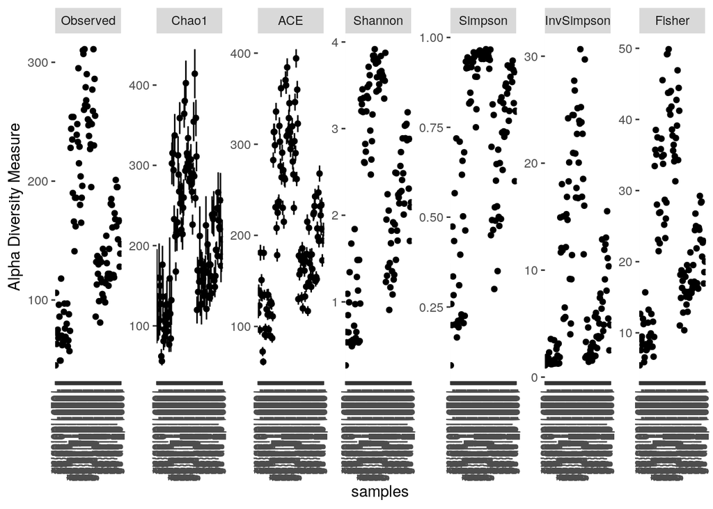

```r
plot_richness(ballou2016)
```

- Represent different samples in a 2 Dimension space

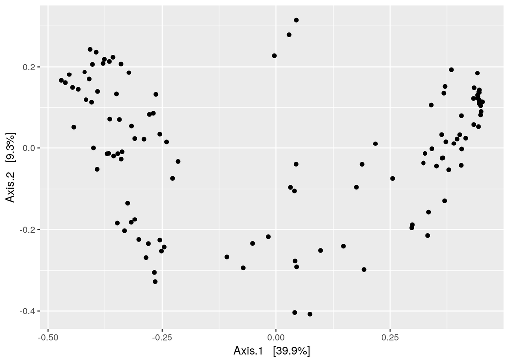

```r
plot_ordination(ballou2016, ordinate(ballou2016,"MDS","bray"))
```

**Exercises:**

1. Remove “singletons” (OTUs present in only one sample).
2. How many control samples (no salmonella vaccine, no probiotics treatment) there are?
3. How many taxa there are when samples are aggregated by Family?
4. Plot alpha diversity, split by treatment, and coloured by age of the chicks
5. Filter phyloseq object to retain only 5% dominant taxa
6. Plot a subset 100 most abundant taxa across all samples:

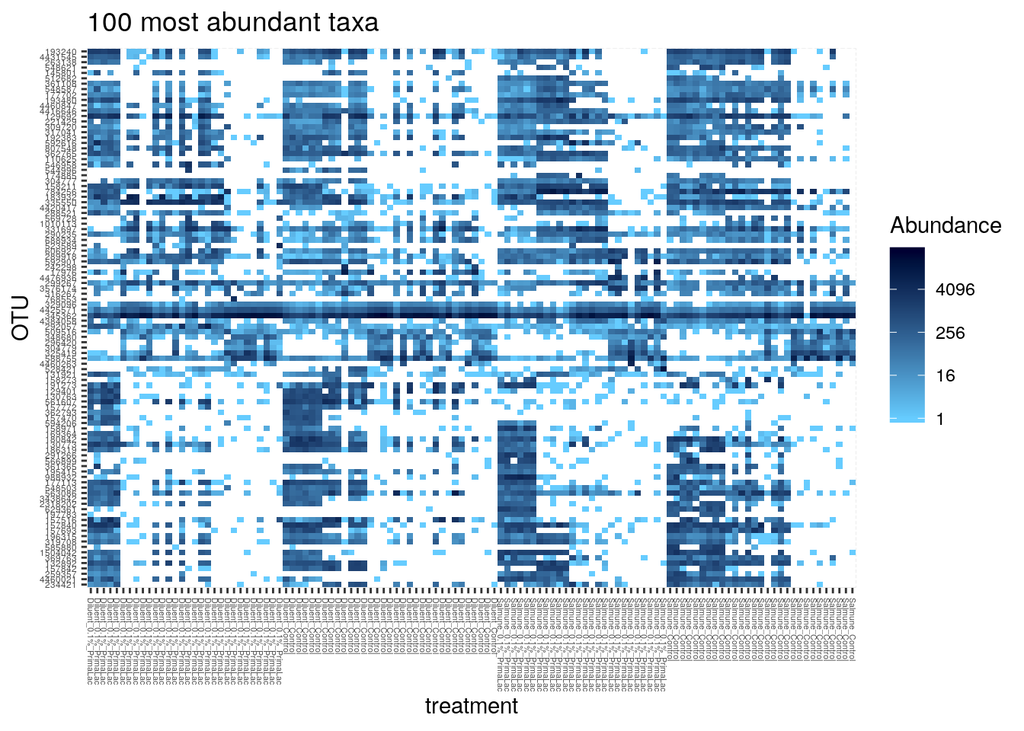

```r
ballou2016.100 <- prune_taxa(names(sort(taxa_sums(ballou2016),TRUE)[1:100]), ballou2016)
plot_heatmap(ballou2016.100, sample.label="treatment",title='100 most abundant taxa', sample.order="treatment", low="#66CCFF", high="#000033", na.value="white")
```

7. Plot samples in a 2D space, with points coloured by age, and different shapes per treatment
8. Get a barplot, where you could distinguish the different taxa associated chicks following different treatments (filter a subset of taxa if you need it)
9. Remove a sample if total sequencing depth fell below the 1st quartile.
10. TSS normalization and multiply by the minimum sequencing depth (that is, the number of reads of the sample with the lowest number of reads). It is a normalization proposal to recover abundances in absolutes terms, although it avoids the bias in the samples with less reads.
11. Remove an OTU if it doesn’t appear in at least a 35% of samples
12. Obtain a phyloseq object where only OTUs with a mean relative abundance greater than 10^-6 are kept.

### MDPbiome

A complete microbiome R project developed with the phyloseq package (among others).  
Code: https://github.com/beatrizgj/MDPbiome  
Reference: [doi: 10.1093/bioinformatics/bty562] (https://doi.org/10.1093/bioinformatics/bty562)

## Data visualization

### Type of chart selection

Each dataset/goal fits better with a type of graph:

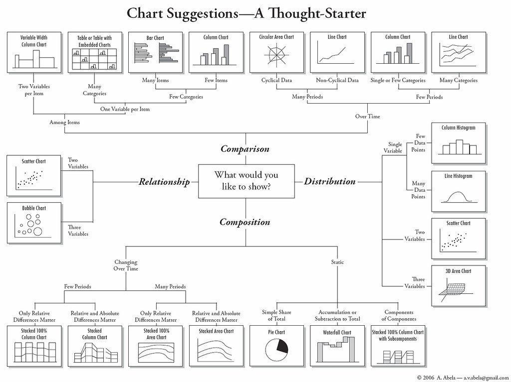

### Graph gallery

[R graph gallery (with code)](https://www.r-graph-gallery.com/)  
Further R: [Data viz catalogue](https://datavizcatalogue.com/index.html)  
Color schemes: [color brewer](http://colorbrewer2.org)

## Clustering

Group data in different clusters is a very often machine learning technique applied in bioinformatics. How to do clustering, to evaluate (usually forgotten) and to interpretate their results with R?

Load a data table:

```r
data=read.table('clusteringSampleData.csv',sep="\t",header=TRUE,row.names=1,check.names=FALSE)
dim(data)
```

```
## [1]   5 214
```

```r
# Transpose to get samples in rows and variables in columns
data=as.data.frame(t(data))
dim(data)
```

```
## [1] 214   5
```

```r
head(data)
```

```
##              EX_o2(e)        GR         CS CYTBO3_4pp NADH16pp
## EX_etoh(e)   2.749599 0.1132880 1.84782574   5.493618 3.752517
## EX_meoh(e)   2.962941 0.1082002 0.09797774   5.920552 5.924507
## EX_2ameph(e) 3.092770 0.1051040 1.89493908   6.180363 4.384439
## EX_btd_RR(e) 2.524966 0.1037400 1.90279131   5.044820 3.239759
## EX_ocdca(e)  2.969718 0.1014141 1.91618101   5.907192 1.985168
## EX_tag180(e) 2.898642 0.1013658 1.78487993   5.765056 2.091189
```

- Run clustering algorithm (hclust):

```r
hc<-hclust(dist(data))
```

#### Clustering evaluation

Check the performance of the clustering, for example, with [Silhouette coefficient](https://www.sciencedirect.com/science/article/pii/0377042787901257), measuring how good the samples are grouped. You can use the average silhouette width, i.e. a unique number averaging silhouette for all clusters and instances. It is a normalized measure between -1 and 1, where:  
* Very strong clustering structure: >0.7 (within distance > between distance)  
* Meaningful clustering structure: >0.25  
* Bad clustering: <0 (instances misclassified)

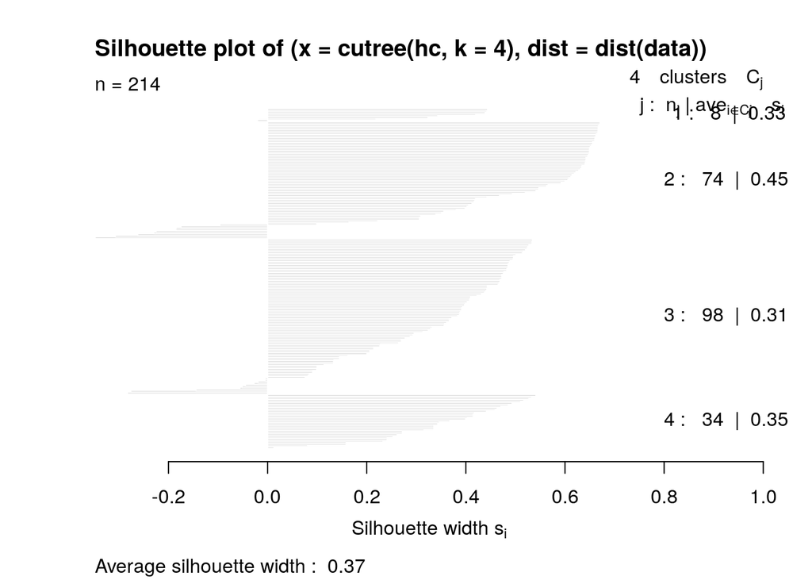

```r
library(cluster)
hc<-hclust(dist(data))
si<-silhouette(cutree(hc,k=4),dist(data))
plot(si)
```

```r
summary(si)$avg.width
```

```
## [1] 0.3664977
```

```r
for(i in 2:10){
  print(paste("k=",i,": ",summary(silhouette(cutree(hc,k=i),dist(data)))$avg.width,sep=''))
} # end-for
```

```
## [1] "k=2: 0.448086025777604"
## [1] "k=3: 0.365053406507022"
## [1] "k=4: 0.366497692240171"
## [1] "k=5: 0.364955254504012"
## [1] "k=6: 0.368719177993593"
## [1] "k=7: 0.344083338713677"
## [1] "k=8: 0.319132403430617"
## [1] "k=9: 0.317167794704789"
## [1] "k=10: 0.341100462813428"
```

#### Clustering visualization

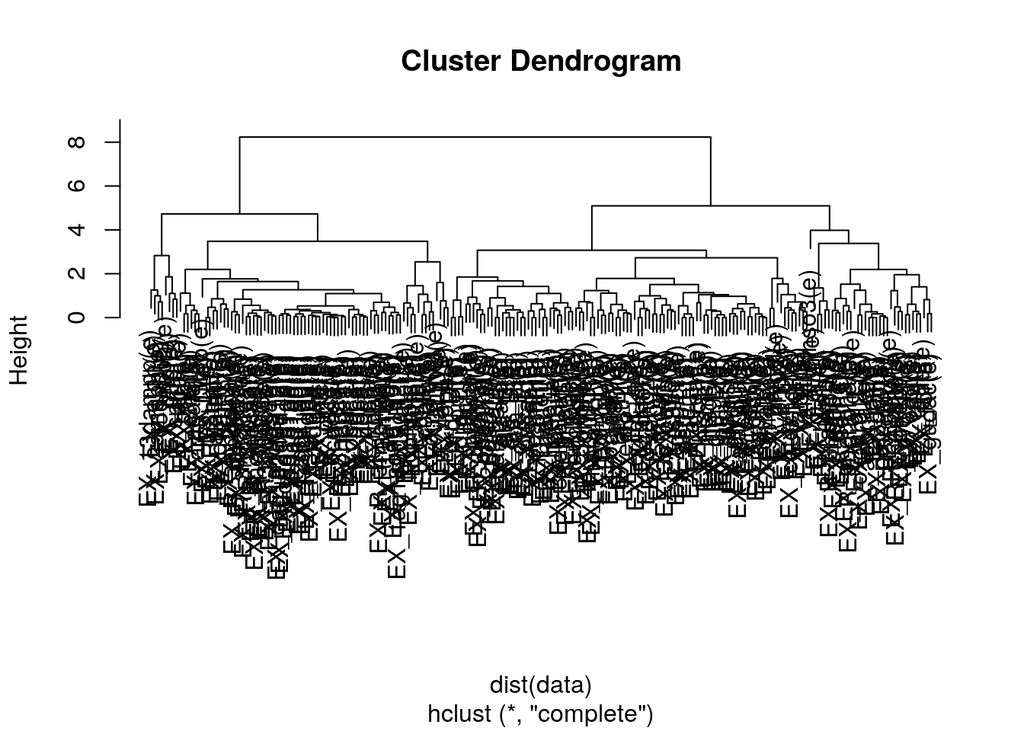

```r
plot(hc)
```

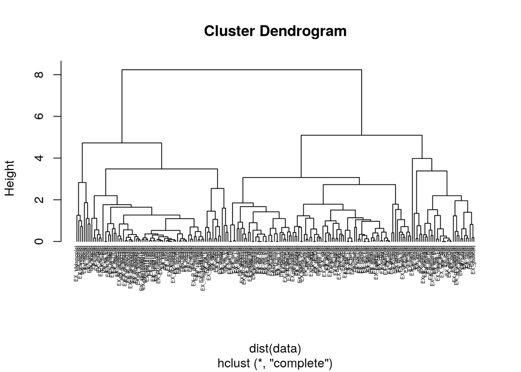

```r
plot(hc,hang=-1,cex=0.4)
```

- Other visualization options:

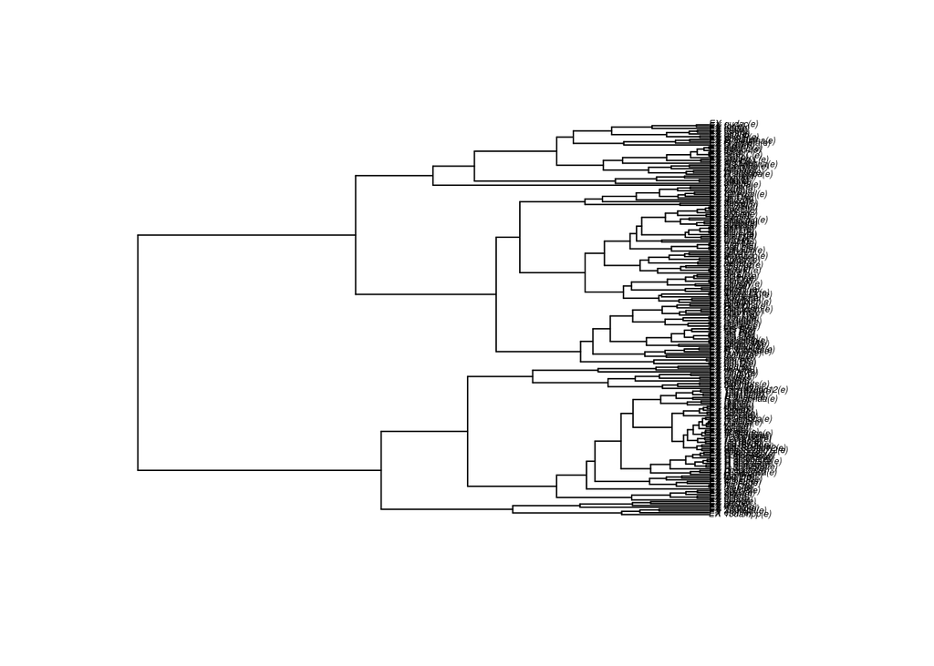

```r
library('ape')
plot(as.phylo(hc),cex=0.4)
```

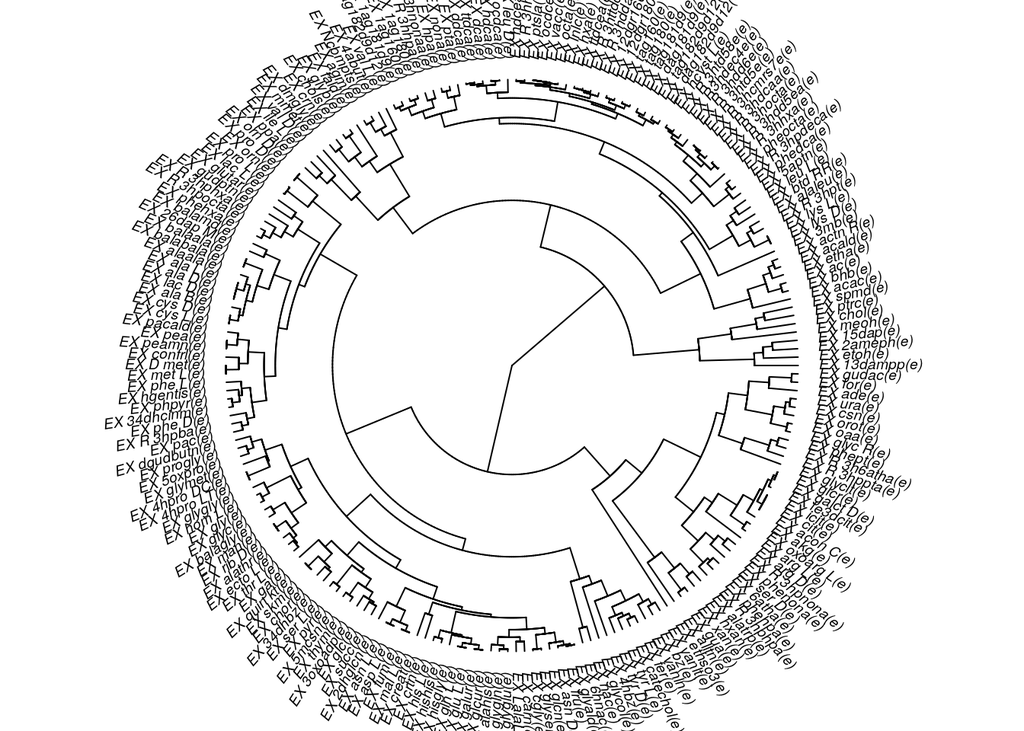

```r
# type='fan'
plot(as.phylo(hc), type = "fan", cex = 0.6, label.offset = 0.3, no.margin=TRUE)
```

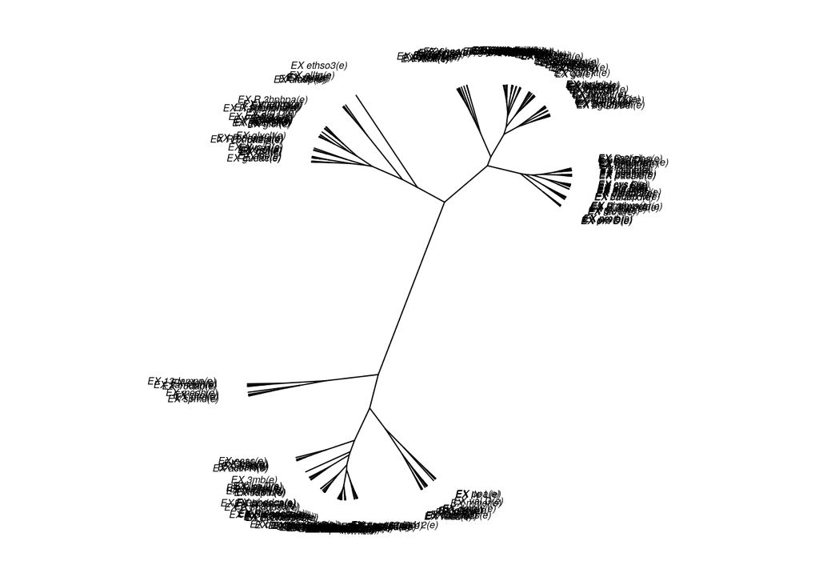

```r
# type='unrooted'
plot(as.phylo(hc), type='unrooted', cex=0.5, label.offset=0.5, no.margin=TRUE)
```

- With colors, after deciding number of clusters:

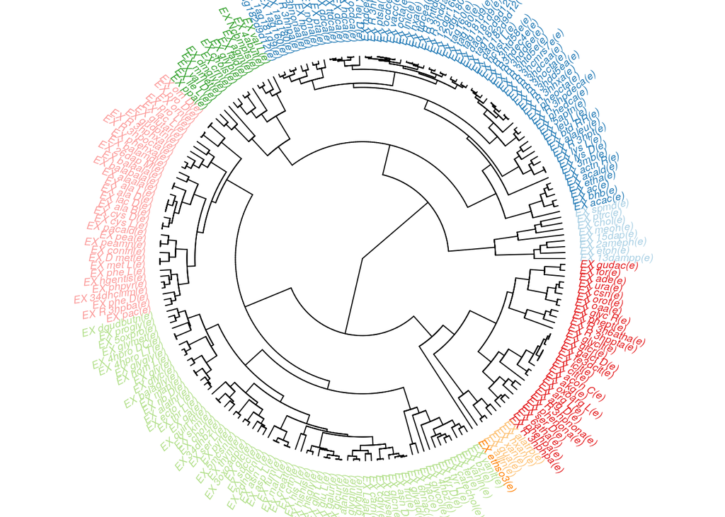

```r
library(RColorBrewer)
k=8
my.palette <- brewer.pal(k,"Paired")
cols <- colorRampPalette(my.palette)(k)
clusK=cutree(hc,k)
plot(as.phylo(hc), type = "fan", cex = 0.6, label.offset = 0.3, no.margin=TRUE, tip.color = cols[clusK])
```

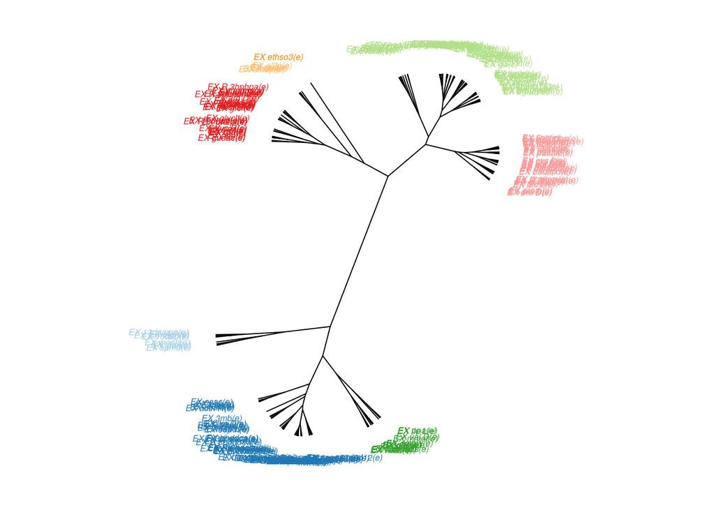

```r
plot(as.phylo(hc), type='unrooted', cex=0.5, label.offset=0.5, no.margin=TRUE, tip.color = cols[clusK])
```

#### Clustering assignation

Save clusters assigned to each instance:

```r
hc<-hclust(dist(data))
k=4
groups <- as.factor(cutree(hc,k=k))
write.table(groups,paste("hclust_clusters_k",k,".txt",sep=""),quote=FALSE,sep='\t',col.names=NA,row.names=TRUE)
```

#### Clusters coloured in scatterplot

With variables in diagonal:

```r
library(car,quietly = TRUE)
```

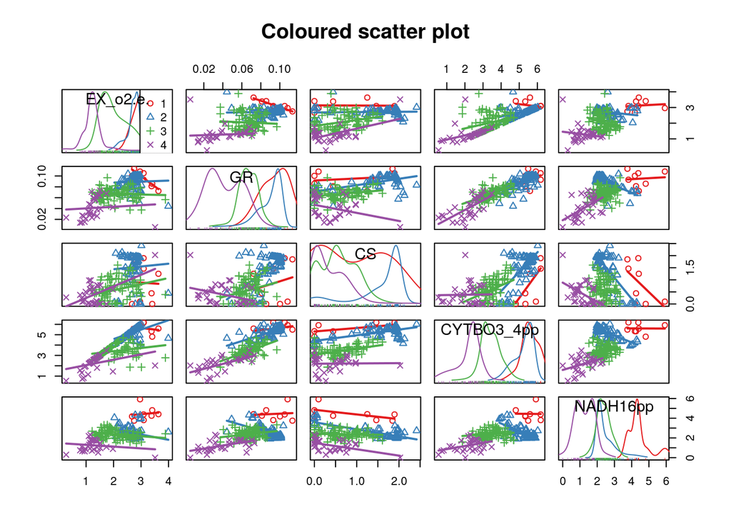

```r
data.withClus=data
 # avoid error due to invalid characters in names
colnames(data.withClus)=make.names(colnames(data.withClus))
 # add a new column to the data.frame
data.withClus$clusters=groups
my_colors <- brewer.pal(nlevels(as.factor(data.withClus$clusters)), "Set1")
formula=formula(paste("~",paste(colnames(data.withClus),collapse="+"),"|clusters",sep=""))
scatterplotMatrix(formula, data=data.withClus, smooth=list(smoother=""), col=my_colors, main="Coloured scatter plot")
```

**Exercises:**  
* How do you save a figure in a .png file?

- To select a kind of non-common plot from R graph gallery, based on your preferences or the usefulness applied to some data you want to represent, and write the code to reproduce the selected graph with your dataset.